# Отчёт по лабораторной работе №7

Анализ файловой системы Linux. Команды для работы с файлами и каталогами

Автор

принадлежность

Терентеевская Светлана Александровна, Student

Российский университет дружбы народов

Дата публикации

2026-03-26

# Информация

## Докладчик

- Терентеевская Светлана Александровна
- Группа НКАбд-05-25, студент бакалавра
- Российский университет дружбы народов им. П. Лумумбы
- 1032253498@rudn.ru
- https://github.com/SvetlanaTerenteevskaya

# Вводная часть

## Цель работы

Ознакомиться с файловой системой Linux, её структурой, командами для работы с файлами и каталогами. Получить практические навыки по применению команд для работы с файлами и каталогами, по управлению процессами, по проверке использования диска и обслуживанию файловой системы.

## Задание

- Ознакомиться с командами для работы с файлами и каталогами и выполнить их
- Выполнить действия по копированию и перемещению файлов
- Изучить права доступа к файлам и каталогам
- Установить заданные права

## Теоретическое введение

### 1. Основные команды для работы с файлами

| Команда | Назначение |
| --- | --- |
| `touch` | создание пустого файла |
| `cat` | просмотр содержимого файла |
| `less` | постраничный просмотр файла |
| `head` | просмотр первых строк файла |
| `tail` | просмотр последних строк файла |
| `cp` | копирование файлов и каталогов |
| `mv` | перемещение и переименование |
| `mkdir` | создание каталога |

### 2. Права доступа

Каждый файл и каталог имеет три типа прав для трёх категорий пользователей:

| Категория | Обозначение |
| --- | --- |
| владелец | `u` (user) |
| группа | `g` (group) |
| остальные | `o` (others) |

| Право | Для файла | Для каталога |
| --- | --- | --- |
| `r` (чтение) | просмотр содержимого | просмотр списка файлов |
| `w` (запись) | изменение и переименование | создание и удаление файлов |
| `x` (выполнение) | запуск программы | доступ в каталог |

Права могут быть заданы в символьном формате (`u+x`, `g-w`, `o=r`) или числовом (восьмеричном) формате, например `755` соответствует `rwxr-xr-x`.

### 3. Анализ файловой системы

Для работы с файловой системой используются следующие команды:

| Команда | Назначение |
| --- | --- |
| `mount` | просмотр смонтированных файловых систем |
| `df` | информация об использовании дискового пространства |
| `fsck` | проверка целостности файловой системы |
| `mkfs` | создание файловой системы |

# Выполнение лабораторной работы

## Выполнение примеров

Я выполнила все примеры, приведенные в первой части лабораторной работы.

Я создала файл abc1 и скопировала его в файл april и в файл may. После чего создала каталог monthly и скопировала файлы april и may в него. А также скопировала файл monthly/may в файл с именем june (рис. 1).

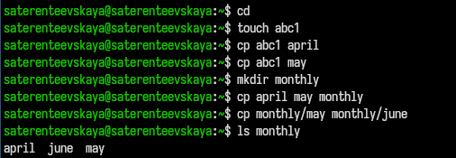

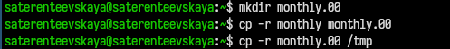

Рисунок 2: Копирование файлов

Я изменила название файла april на july, переместила его в каталог monthly.00. Далее переименовла monthly.00 в monthly.01 и переместила его в катлог reports. После чего переименовала каталог reports/monthly.01 в reports/monthly (рис. 3).

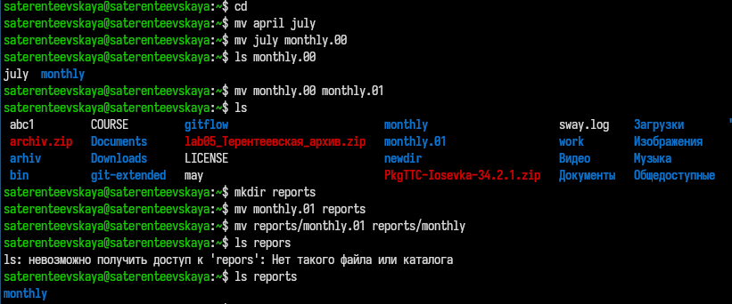

Рисунок 3: Перемещение и переименовывание файлов

Я создала файл may с правом выполнения для владельца, лишила его прав на выполнения. Потом создала каталог monthly с запретом на чтение для членов группы и всех остальных пользователей, а также создала файл abc1 с правом записи для членов группы (рис. 4).

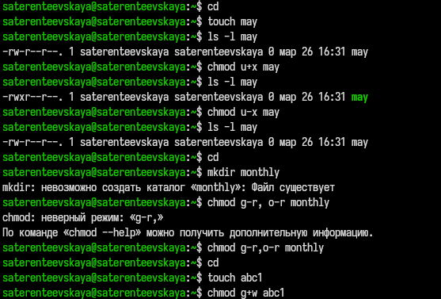

Рисунок 4: Права доступа

Я использовала команду mount для просмотра используемых файловых систем (рис. 5).

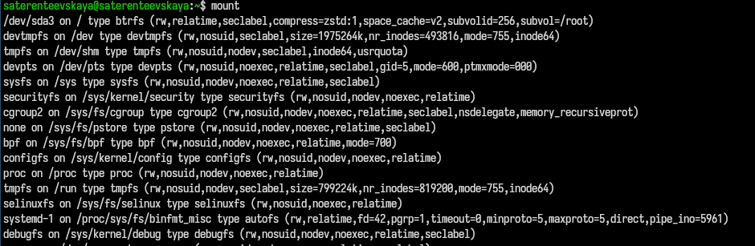

Рисунок 5: Ппросмотр используемых файловых систем

Для определения объема свободного пространства на файловой системе я воспользовалась командой df (рис. 6).

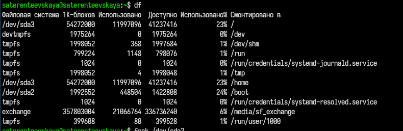

Рисунок 6: Определение объема свободного пространства

Проверила целостность файловой системы (рис. 7).

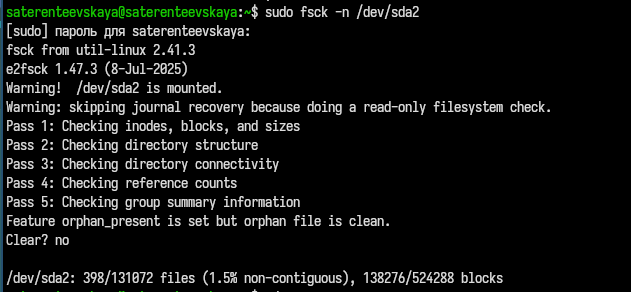

Рисунок 7: Проверка целостности файловой системы

## Создание и перемещение файлов

Я скопировала файл /usr/include/sys/io.h в домашний каталог и назвала его equipment. Проверила что он переместился (рис. 8).

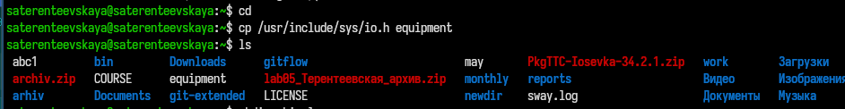

Рисунок 8: Копирование файла io.h

В домашнем каталоге создала директорию ~/ski.plases, переместила файл equipment в каталог ~/ski.plases и переименовала файл ~/ski.plases/equipment в ~/ski.plases/equiplist (рис. 9).

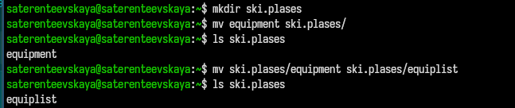

Рисунок 9: Создание директории и каталог equipment

Я создала в домашнем каталоге файл abc1, скопировала его в каталог ~/ski.plases и назвала equiplist2. Потом создала каталог с именем equipment в каталоге ~/ski.plases и переместила файлы ~/ski.plases/equiplist и equiplist2 в каталог ~/ski.plases/equipment. Проверила командой ls (рис. 10).

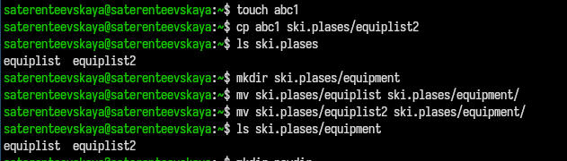

Рисунок 10: Перемещение файлов по ski.plases

## 3. Работа с правами доступа

Создала и переместила каталог ~/newdir в каталог ~/ski.plases и назвала его plans (рис. 11).

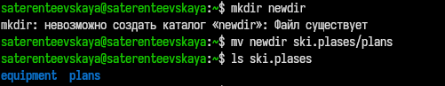

Рисунок 11: Создание и перемещение каталога newdir

Далее я создала каталоги australia и play, а также файлы my_os и feathers и определила опции команды chmod, необходимые для того, чтобы присвоить им выделенные права доступа (рис. 12,рис. 13).

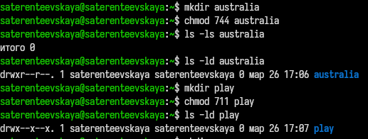

Рисунок 12: Создание и выделение прав для каталогов

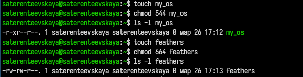

Рисунок 13: Создание и выделение прав для файлов

## Копирование файлов и смена прав доступа

Я просмотрела содержимое файла /etc/passwd (рис. 14).

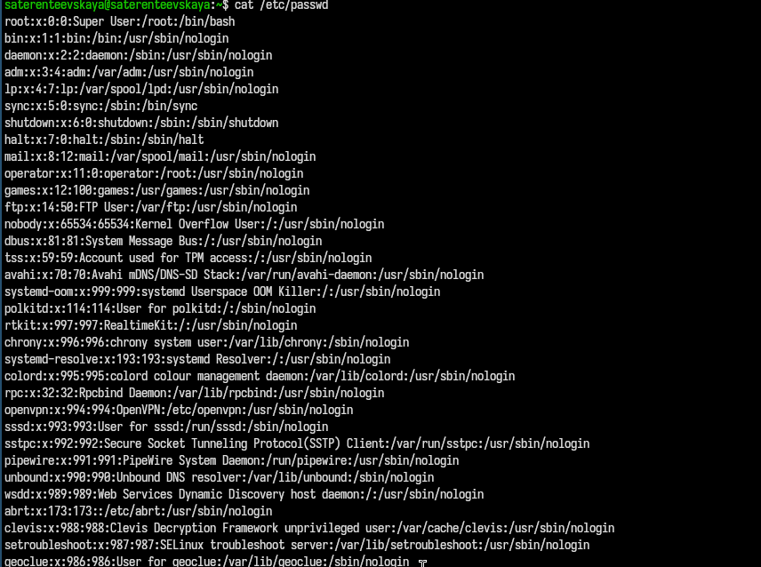

Рисунок 14: Содержимое файла passwd

Я скопировала файл ~/feathers в файл ~/file.old и переместила файл ~/file.old в каталог ~/play (рис. 15).

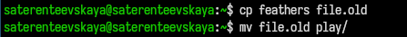

Рисунок 15: Копирование и перемещение файлов

Я скопировала каталог ~/play в каталог ~/fun и переместила каталог ~/fun в каталог ~/play и назвала его games (рис. 16).

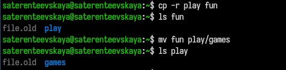

Рисунок 16: Копирование и перемещение каталогов

Я лишила владельца файла ~/feathers права на чтение. Я попыталась просмотреть файл ~/feathers командой cat, но выдало: Отказано в доступе. Я попыталась скопировать файл ~/feathers, на что также отказано в доступе. После этого я дала владельцу файла ~/feathers право на чтение (рис. 17).

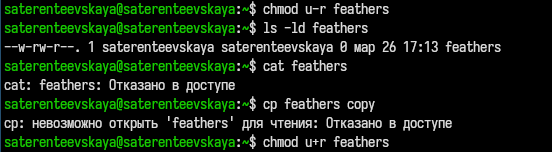

Рисунок 17: Лишение прав feathers

Я лишила владельца каталога ~/play права на выполнение. Попробовала перейти в каталог ~/play, мне было отказано в доступе. Я дала владельцу каталога ~/play право на выполнение (рис. 18).

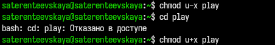

Рисунок 18: Лишение прав play

## Команда man и описание команд mount, fsck, mkfs, kill

Я прочитала man по команде mount (рис. 19).

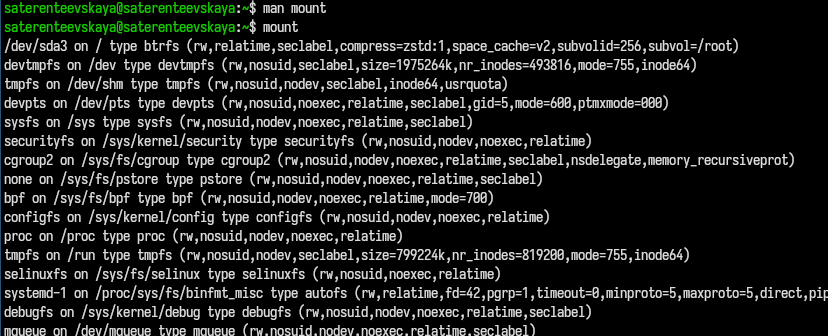

Рисунок 19: Команда mount

Подключает диск, флешку или раздел к системе, чтобы с ним можно было работать

Я прочитала man по команде fsck (рис. 20).

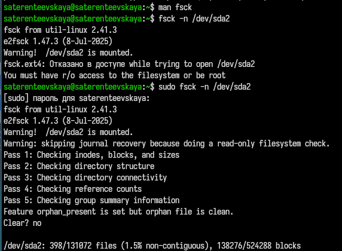

Рисунок 20: Команда fsck

Проверяет диск на ошибки и исправляет их

Я прочитала man по команде mkfs (рис. 21).

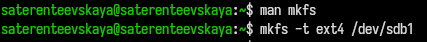

Рисунок 21: Команда mkfs

Создает файловую систему на диске (форматирует диск)

Завершает работающую программу (процесс) по ее номеру (PID)

# Выводы

В ходе выполнения рабораторной работы я ознакомилась с файловой системой Linux, её структурой, командами для работы с файлами и каталогами. Получила практические навыки по применению команд для работы с файлами и каталогами, по управлению процессами, по проверке использования диска и обслуживанию файловой системы.

# Список литературы

ТУИС

[Методичка к лабораторной работе №7](https://esystem.rudn.ru/mod/resource/view.php?id=1358193php)